# Weekly Exercises #6

Ellery Island

```r
library(tidyverse)     # for data cleaning and plotting
library(gardenR)       # for Lisa's garden data
library(lubridate)     # for date manipulation
library(openintro)     # for the abbr2state() function
library(palmerpenguins)# for Palmer penguin data
library(maps)          # for map data
library(ggmap)         # for mapping points on maps
library(gplots)        # for col2hex() function
library(RColorBrewer)  # for color palettes
library(sf)            # for working with spatial data
library(leaflet)       # for highly customizable mapping
library(ggthemes)      # for more themes (including theme_map())
library(plotly)        # for the ggplotly() - basic interactivity
library(gganimate)     # for adding animation layers to ggplots
library(gifski)        # for creating the gif (don't need to load this library every time,but need it installed)
library(transformr)    # for "tweening" (gganimate)
library(shiny)         # for creating interactive apps
library(patchwork)     # for nicely combining ggplot2 graphs
library(gt)            # for creating nice tables
library(rvest)         # for scraping data
library(robotstxt)     # for checking if you can scrape data
theme_set(theme_minimal())
```

```r
# Lisa's garden data
data("garden_harvest")

#COVID-19 data from the New York Times
covid19 <- read_csv("https://raw.githubusercontent.com/nytimes/covid-19-data/master/us-states.csv")
```

## Put your homework on GitHub!

Go [here](https://github.com/llendway/github_for_collaboration/blob/master/github_for_collaboration.md) or to previous homework to remind yourself how to get set up.

Once your repository is created, you should always open your **project** rather than just opening an .Rmd file. You can do that by either clicking on the .Rproj file in your repository folder on your computer. Or, by going to the upper right hand corner in R Studio and clicking the arrow next to where it says Project: (None). You should see your project come up in that list if you’ve used it recently. You could also go to File –> Open Project and navigate to your .Rproj file.

## Instructions

- Put your name at the top of the document.
- **For ALL graphs, you should include appropriate labels.**
- Feel free to change the default theme, which I currently have set to `theme_minimal()`.
- Use good coding practice. Read the short sections on good code with [pipes](https://style.tidyverse.org/pipes.html) and [ggplot2](https://style.tidyverse.org/ggplot2.html). **This is part of your grade!**
- **NEW!!** With animated graphs, add `eval=FALSE` to the code chunk that creates the animation and saves it using `anim_save()`. Add another code chunk to reread the gif back into the file. See the [tutorial](https://animation-and-interactivity-in-r.netlify.app/) for help.
- When you are finished with ALL the exercises, uncomment the options at the top so your document looks nicer. Don’t do it before then, or else you might miss some important warnings and messages.

## Warm-up exercises from tutorial

1. Read in the fake garden harvest data. Find the data [here](https://github.com/llendway/scraping_etc/blob/main/2020_harvest.csv) and click on the `Raw` button to get a direct link to the data. After reading in the data, do one of the quick checks mentioned in the tutorial.

```r
X2020_harvest <- read_csv("https://raw.githubusercontent.com/llendway/scraping_etc/main/2020_harvest.csv",
    col_types = cols(...1 = col_skip(),
                    date = col_date(format = "%m/%d/%y"),
                    weight = col_number()),
    na = "MISSING",
    skip = 2)

summary(X2020_harvest)
```

```
##   vegetable           variety               date                weight
##  Length:685         Length:685         Min.   :2020-06-06   Min.   :   2
##  Class :character   Class :character   1st Qu.:2020-07-21   1st Qu.:  87
##  Mode  :character   Mode  :character   Median :2020-08-09   Median : 252
##                                        Mean   :2020-08-08   Mean   : 504
##                                        3rd Qu.:2020-08-26   3rd Qu.: 599
##                                        Max.   :2020-10-03   Max.   :7350
##                                                             NA's   :4
##     units
##  Length:685
##  Class :character
##  Mode  :character
##
##
##
##
```

2. Read in this [data](https://www.kaggle.com/heeraldedhia/groceries-dataset) from the kaggle website. You will need to download the data first. Save it to your project/repo folder. Do some quick checks of the data to assure it has been read in appropriately.

```r
groceries <- read_csv("Groceries_dataset.csv")
```

3. Create a table using `gt` with data from your project or from the `garden_harvest` data if your project data aren’t ready. Use at least 3 `gt()` functions.

```r
gt(garden_harvest)%>%
  fmt_date(date)%>%
  tab_header(title = "Garden Data")%>%
  opt_table_outline(style = "solid", width = px(3))
```

Garden Data

| vegetable | variety | date | weight | units |
| --- | --- | --- | --- | --- |
| lettuce | reseed | Saturday, June 6, 2020 | 20 | grams |
| radish | Garden Party Mix | Saturday, June 6, 2020 | 36 | grams |
| lettuce | reseed | Monday, June 8, 2020 | 15 | grams |
| lettuce | reseed | Tuesday, June 9, 2020 | 10 | grams |
| radish | Garden Party Mix | Thursday, June 11, 2020 | 67 | grams |
| lettuce | Farmer's Market Blend | Thursday, June 11, 2020 | 12 | grams |
| spinach | Catalina | Thursday, June 11, 2020 | 9 | grams |
| beets | leaves | Thursday, June 11, 2020 | 8 | grams |
| radish | Garden Party Mix | Saturday, June 13, 2020 | 53 | grams |
| lettuce | Farmer's Market Blend | Saturday, June 13, 2020 | 19 | grams |
| spinach | Catalina | Saturday, June 13, 2020 | 14 | grams |
| kale | Heirloom Lacinto | Saturday, June 13, 2020 | 10 | grams |
| lettuce | Farmer's Market Blend | Wednesday, June 17, 2020 | 48 | grams |
| spinach | Catalina | Wednesday, June 17, 2020 | 58 | grams |
| peas | Magnolia Blossom | Wednesday, June 17, 2020 | 8 | grams |
| peas | Super Sugar Snap | Wednesday, June 17, 2020 | 121 | grams |
| chives | perrenial | Wednesday, June 17, 2020 | 8 | grams |
| strawberries | perrenial | Thursday, June 18, 2020 | 40 | grams |
| lettuce | Farmer's Market Blend | Thursday, June 18, 2020 | 47 | grams |
| spinach | Catalina | Thursday, June 18, 2020 | 59 | grams |
| beets | leaves | Thursday, June 18, 2020 | 25 | grams |
| spinach | Catalina | Friday, June 19, 2020 | 58 | grams |
| lettuce | Farmer's Market Blend | Friday, June 19, 2020 | 39 | grams |
| beets | leaves | Friday, June 19, 2020 | 11 | grams |
| lettuce | Farmer's Market Blend | Friday, June 19, 2020 | 38 | grams |
| lettuce | Farmer's Market Blend | Saturday, June 20, 2020 | 22 | grams |
| spinach | Catalina | Saturday, June 20, 2020 | 25 | grams |
| lettuce | Tatsoi | Saturday, June 20, 2020 | 18 | grams |
| radish | Garden Party Mix | Saturday, June 20, 2020 | 16 | grams |
| peas | Magnolia Blossom | Saturday, June 20, 2020 | 71 | grams |

[output cut: 751 more lines]

4. CHALLENGE (not graded): Write code to replicate the table shown below (open the .html file to see it) created from the `garden_harvest` data as best as you can. When you get to coloring the cells, I used the following line of code for the `colors` argument:

```r
#colors = scales::col_numeric(
      #palette = paletteer::paletteer_d(
       # palette = "RColorBrewer::YlGn"
      #) %>% as.character()
```

5. Use `patchwork` operators and functions to combine at least two graphs using your project data or `garden_harvest` data if your project data aren’t read.

```r
library(geomtextpath)
```

```r
garden_harvest_new <- garden_harvest%>%
  mutate(Vegetable = str_to_title(vegetable))%>%
  select(Vegetable, weight, date)%>%
  group_by(date, Vegetable)%>%
  summarize(total = sum(weight))%>%
  group_by(Vegetable) %>%
  mutate(cum_weight = cumsum(total))%>%
  filter(Vegetable %in% c("Lettuce", "Kale", "Spinach", "Swiss Chard"))
```

```r
g1<- ggplot(garden_harvest_new, aes(x = date, y = cum_weight, color = Vegetable, label = Vegetable))+
    geom_line(size = .6, se = FALSE) +
    geom_textline(size = 4, fontface = "bold", vjust = 0, hjust = "xmax", text_smoothing = 35) +
    scale_color_manual(values = c("Kale" = "deepskyblue4",
                                "Lettuce" ="orangered1",
                                "Spinach" = "cadetblue3",
                                "Swiss Chard" = "goldenrod2"))+
    theme(text = element_text(family = "Avenir"))+
    theme(legend.position = "none")+
    labs(title = "Cumulative Harvest of Leafy Greens",
         x = NULL,
         y = NULL) +
    theme(panel.grid.major.x = element_blank(),
        panel.grid.minor.x = element_blank(),
        panel.background = element_blank(),
        panel.grid.major.y = element_line(size = .1, color = "gray85" ))
```

```r
g2 <- garden_harvest_new%>%
  filter(cum_weight == max(cum_weight))%>%
  ggplot(aes(y = cum_weight, x = Vegetable, fill = Vegetable, label = Vegetable))+
  geom_col()+
      scale_fill_manual(values = c("Kale" = "deepskyblue4",
                                "Lettuce" ="orangered1",
                                "Spinach" = "cadetblue3",
                                "Swiss Chard" = "goldenrod2")) +
  labs(y = NULL, x = NULL)+
  theme(panel.grid.major.x = element_blank(),
        panel.grid.minor.x = element_blank(),
        panel.background = element_blank(),
        panel.grid.major.y = element_line(size = .1, color = "gray85" ))+
  theme(legend.position = "none")
```

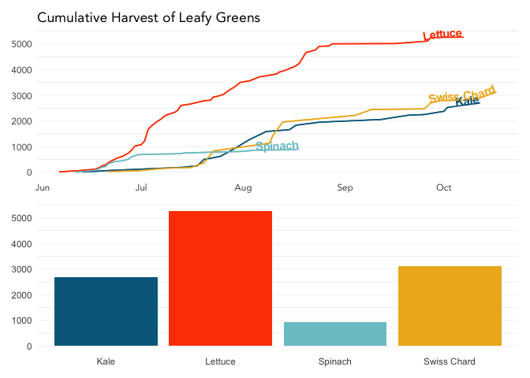

```r
g1 / g2
```

## Webscraping exercise (also from tutorial)

Use the data from the [Macalester Registrar’s Fall 2017 Class Schedule](https://www.macalester.edu/registrar/schedules/2017fall/class-schedule/#crs10008) to complete all these exercises.

6. Find the correct selectors for the following fields. Make sure that each matches 762 results:
- Course Number - .class-schedule-course-number
- Course Name - .class-schedule-course-title
- Day - .class-schedule-course-title+ .class-schedule-label
- Time - .class-schedule-label:nth-child(4)
- Room - .class-schedule-label:nth-child(5)
- Instructor - .class-schedule-label:nth-child(6)
- Avail. / Max - .class-schedule-label:nth-child(7)
- General Education Requirements (make sure you only match 762; beware of the Mac copyright banner at the bottom of the page!) - #content p:nth-child(2)
- Description - .collapsed p:nth-child(1)

Then, put all this information into one dataset (tibble or data.frame) Do not include any extraneous information like “Instructor:”.

```r
fall2017 <- read_html("https://www.macalester.edu/registrar/schedules/2017fall/class-schedule/#crs10008")
```

```r
course_nums <-
  fall2017 %>%
  html_elements(".class-schedule-course-number") %>%
  html_text2()

course_names <-
  fall2017 %>%
  html_elements(".class-schedule-course-title") %>%
  html_text2()

course_days <- fall2017 %>%
  html_elements("td.class-schedule-label:nth-child(3)") %>%
  html_text2() %>%
  str_sub(start = 7)

course_times <-
  fall2017 %>%
  html_elements(".class-schedule-label:nth-child(4)") %>%
  html_text2() %>%
  str_sub(start = 7)

course_room <-
  fall2017 %>%
  html_elements(".class-schedule-label:nth-child(5)") %>%
  html_text2() %>%
  str_sub(start = 7)

course_instructor <-
  fall2017 %>%
  html_elements(".class-schedule-label:nth-child(6)") %>%
  html_text2() %>%
  str_sub(start = 13)

course_avail_max <-
  fall2017 %>%
  html_elements(".class-schedule-label:nth-child(7)") %>%
  html_text2() %>%
  str_sub(start = 14)

course_gen_ed <-
  fall2017 %>%
  html_elements("#content p:nth-child(2)") %>%
  html_text2()%>%
  str_sub(start = 34)

course_description <-
  fall2017 %>%
  html_elements(".collapsed p:nth-child(1)") %>%
  html_text2()%>%
  str_sub(start = 3)

courses_2017 <- tibble(number=course_nums, name=course_names, day = course_days, times = course_times, room = course_room, instructor = course_instructor, avail_max = course_avail_max, gen_ed = course_gen_ed, description = course_description)
head(courses_2017)
```

| number | name | day | times | room | instructor | avail_max | gen_ed | description |
| --- | --- | --- | --- | --- | --- | --- | --- | --- |
| AMST 101-01 | Explorations of Race and Racism | W | 07:00 pm-10:00 pm | ARTCOM 102 | Gutierrez, Harris | Closed -5 / 25 | U.S. Identities and Differences\n | The main objectives of this introductory course are: to explore the historical construction of racial categories in the United States; to understand the systemic impact of racism on contemporary socia… |
| AMST 103-01 | The Problems of Race in US Social Thought and Policy | MWF | 09:40 am-10:40 am | NEILL 111 | Karin Aguilar-San Juan | 0 / 16 | U.S. Identities and Differences\nWriting WA\n | In this discussion-based and residential course, we will explore the paradox of a society in which people are increasingly aware of patterns of racism and yet still unable to see or explain how those … |
| AMST 200-01 | Critical Methods for American Studies Research | MWF | 02:20 pm-03:20 pm | OLRI 205 | Nathan Titman | 13 / 20 |  | This course will introduce students to interdisciplinary research approaches to the study of race, ethnicity, and other categories of difference. Students will learn to conceptualize and design resear… |
| AMST 203-01 | Politics and Inequality: American Welfare State | MWF | 09:40 am-10:40 am | CARN 204 | Lesley Lavery | Closed 0 / 25 | U.S. Identities and Differences\nWriting WP\n | Americans, at least since the Founding era, have cherished the ideal of political equality. Unlike European nations, the United States did not inherit economic class distinctions from a feudal past. B… |
| AMST 219-01 | In Motion: African Americans in the United States | MWF | 01:10 pm-02:10 pm | MAIN 010 | Crystal Moten | 2 / 20 | U.S. Identities and Differences\n | In Motion is an introduction to modern African American History from slavery to contemporary times. In Motion emphasizes the idea that both African Americans and the stories of their lives in the Unit… |
| AMST 229-01 | Narrating Black Women's Resistance | MWF | 10:50 am-11:50 am | MAIN 001 | Crystal Moten | Closed 4 / 14 |  | This course examines traditions of 20th century African American women’s activism and the ways in which they have changed over time. Too often, the narrative of the “strong black woman” infuses storie… |

7. Create a graph that shows the number of sections offered per department. Hint: The department is a substring of the course number - there are `str_XXX()` functions that can help. Yes, COMP and MATH are the same department, but for this exercise you can just show the results by four letter department code, e.g., with COMP and MATH separate.

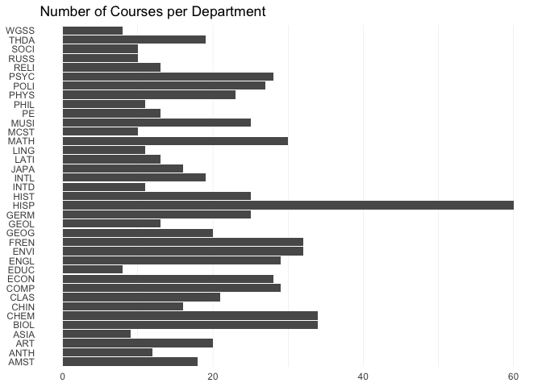

```r
courses_2017%>%
  separate(number, into = c("department", "number", "section")) %>%
  group_by(department) %>%
  summarize(n_courses = n()) %>%
  ggplot(aes(y = department, x = n_courses)) +
    geom_col()+
  labs(x = NULL, y = NULL, title = "Number of Courses per Department")+
  theme(panel.grid.major.x = element_line(size = .1, color = "gray85" ),
        panel.grid.minor.x = element_line(size = .1, color = "gray85" ),
        panel.background = element_blank(),
        panel.grid.major.y = element_blank())
```

8. Analyze the typical length of course names by department. To do so, create a new data table based on your courses data table, with the following changes:
- New columns for the length of the title of a course and the length of the description of the course. Hint: `str_length`.
- Remove departments that have fewer than 10 sections of courses. To do so, group by department, then remove observations in groups with fewer than 10 sections (Hint: use filter with n()). Then `ungroup()` the data.
- Create a visualization of the differences across groups in lengths of course names or course descriptions. Think carefully about the visualization you should be using!

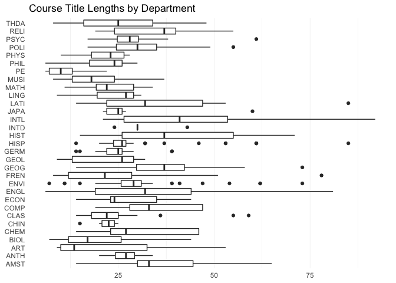

```r
courses_2017%>%
  separate(number, into = c("department", "number", "section")) %>%
  mutate(title_length = str_length(name))%>%
  group_by(department)%>%
  filter(n()>10)%>%
  ungroup()%>%
  ggplot(aes(y = department, x = title_length))+
    geom_boxplot() +
  labs(title = "Course Title Lengths by Department", x = NULL, y = NULL)+
    theme(panel.grid.major.x = element_line(size = .1, color = "gray85" ),
        panel.grid.minor.x = element_line(size = .1, color = "gray85" ),
        panel.background = element_blank(),
        panel.grid.major.y = element_blank())
```

git hub link: https://github.com/elleryisland/exercise_06